# Fitting univariate state-space models

SOE 592 – Intro to Time Series Analysis

4 Jan 2024

# Fitting models

## Simulate a Gompertz model

Simulate the AR(1) state model

```r
## number of time steps
TT <- 40
## strength of density-dependence (0 < b < 1)
bb <- 0.5
## time series of process errors with SD = 1
ww <- rnorm(TT, 0, 0.5)
## initialize state & set x0 = w0
xx <- ww
## loop over time steps
for(t in 2:TT) {
  xx[t] <- bb * xx[t-1] + ww[t]
}
```

## Simulate a Gompertz model

Add some observation error

```r
## obs errors with SD = 0.5
vv <- rnorm(TT, 0, 0.5)
## obs data
yy <- xx + vv
```

## Fitting models with `MARSS()`

We can use the **{MARSS}** pkg for R to fit state-space models

To do so, we must write the model out just as we would on a white board

## Fitting models with `MARSS()`

Here are the main function arguments

```r
MARSS(y, model = NULL, inits = NULL, control = NULL, ...)
```

- `y` is an $n \times T$ `matrix` of data (observations)
- `model` a `list` that defines the state-space model in terms of parameters to be estimated
- `inits` [*optional*] a `list` of initial values for parameters to be estimated
- `control` [*optional*] a `list` of options for controlling fitting algorithms, setting tolerance & convergence parameters, etc

## Fitting models with `MARSS()`

`MARSS()` uses an expanded form of state-space model, such that our biased random walk

$$\begin{align}
x_t &= x_{t-1} + u + w_t \\
y_t &= x_t + v_t
\end{align}$$
instead becomes

$$\begin{align}
x_t &= b x_{t-1} + u + w_t \\
y_t &= Z x_t + a + v_t
\end{align}$$

with $b = 1$, $Z = 1$, and $a = 0$

## Fitting models with `MARSS()`

State model  
$x_t = b x_{t-1} + u + w_t ~~ \text{with} ~~ w_t \sim \text{N}(0,q)$

Observation model  
$y_t = Z x_t + a + v_t ~~ \text{with} ~~ v_t \sim \text{N}(0,r)$

```r
mod_list <- list(
  ## state model
  B = matrix(1), U = matrix("u"), Q = matrix("q"),
  ## obs model
  Z = matrix(1), A = matrix(0), R = matrix("r")
  )
```

**Note**: `MARSS()` works with the `matrix` class in **R**, so we have to define any scalar as a $1 \times 1$ matrix

## Fitting models with `MARSS()`

What about the initial state $x_0$?

$$x_0 \sim \text{N}(\pi,\lambda)$$

Estimating both $\pi$ and $\lambda$ is nearly impossible, so the default is to treat $x_0$ as fixed, but unknown, effect rather than as a random effect, such that

$$x_0 \sim \text{N}(\pi,0)$$

`MARSS()` will do this for us

## Fitting models with `MARSS()`

We can ignore the `inits` and `control` arguments for now and fit the model

```r
## load MARSS package
library(MARSS)
## define the data as an N (rows) x T (cols) matrix
dat <- matrix(yy, nrow = 1, ncol = TT)
## fit the model
mod_fit <- MARSS(y = dat, model = mod_list)
```

## Fitting models with `MARSS()`

```
## Success! algorithm run for 15 iterations. abstol and log-log tests passed.
## Alert: conv.test.slope.tol is 0.5.
## Test with smaller values (<0.1) to ensure convergence.
##
## MARSS fit is
## Estimation method: kem
## Convergence test: conv.test.slope.tol = 0.5, abstol = 0.001
## Algorithm ran 15 (=minit) iterations and convergence was reached.
## Log-likelihood: -42.13614
## AIC: 92.27227   AICc: 93.41513
##
##       Estimate
## R.r    0.24492
## U.u   -0.00446
## Q.q    0.12103
## x0.x0  0.30636
## Initial states (x0) defined at t=0
##
## Standard errors have not been calculated.
## Use MARSSparamCIs to compute CIs and bias estimates.
```

## A note on model fitting

When we have 2+ observations of process, our estimates of model parameters are much more accurate and precise.

$$\begin{align}
x_t &= x_{t-1} + u + w_t ~~ \text{with} ~ w_t \sim \text{N}(0,q) \\
~ \\
\begin{bmatrix}
y_1 \\
y_2 \\
\vdots \\
y_n
\end{bmatrix}_t
&=
\begin{bmatrix}
1 \\
1 \\
\vdots \\
1
\end{bmatrix}
x_t +
\begin{bmatrix}
v_1 \\
v_2 \\
\vdots \\
v_n
\end{bmatrix}_t
~~ \text{with} ~
\mathbf{v_t} \sim \text{MVN}(\mathbf{0},\mathbf{R})
\end{align}$$

## Extracting fitted model objects

Fitted values are stored in an $N \times T$ matrix (here $N = 1$) accessed with `$states`

Standard errors of fitted values are stored in an $N \times T$ matrix (vector) accessed with `$states.se`

```r
## T x 1 (transposed) vector of states
mod_fits <- t(mod_fit$states)

## T x 1 (transposed) vector of SE's
mod_fits_SE <- t(mod_fit$states.se)
```

## Approximate confidence intervals

We can estimate a $[(1 - \alpha) \times 100]\%$ confidence interval as

$$\hat{x} ~ \pm ~ t_{1 - \alpha/2} \times \text{SE}(\hat{x})$$

## Approximate confidence intervals

```r
## upper 95% CI
mod_fits_CI_hi <- mod_fits + qt(p = 0.975, df = TT - 1) * mod_fits_SE

## lower 95% CI
mod_fits_CI_lo <- mod_fits - qt(p = 0.975, df = TT - 1) * mod_fits_SE
```

## Model fit and true states

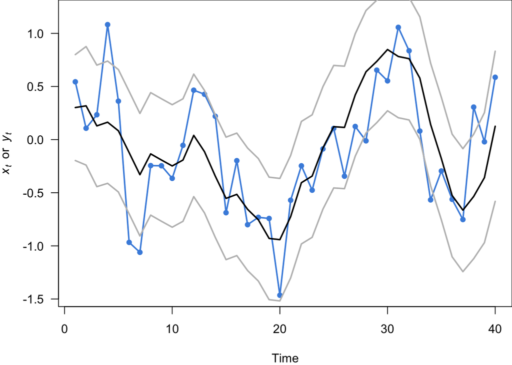

```r
par(mai = c(0.8,0.8,0,0), omi = c(0,0,0,0))
plot.ts(xx, lwd = 2, type = "o", pch = 16, col = "#488fdf",
        las = 1, ylim = c(min(xx,yy), max(xx,yy)),
        ylab = expression(italic(x[t])~~or~~italic(y[t])))
# lines(yy, lwd = 2, type = "o", pch = 16, cex = 1.5, col = "#844870")
lines(mod_fits, lwd = 2, type = "l", cex = 1.5, col = "black")
lines(mod_fits_CI_hi, lwd = 2, type = "l", cex = 1.5, col = "gray")
lines(mod_fits_CI_lo, lwd = 2, type = "l", cex = 1.5, col = "gray")
```

## Model fit with observations only

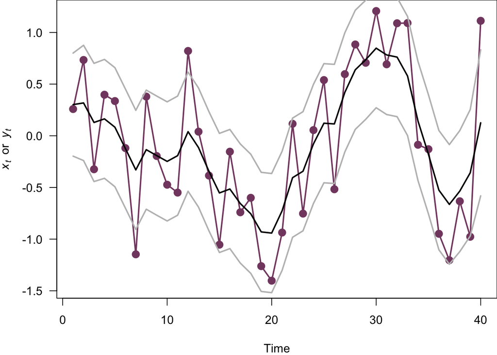

```r
par(mai = c(0.8,0.8,0,0), omi = c(0,0,0,0))
plot.ts(yy, lwd = 2, type = "o", pch = 16, cex = 1.5, col = "#844870",
        las = 1, ylim = c(min(xx,yy), max(xx,yy)),
        ylab = expression(italic(x[t])~~or~~italic(y[t])))
lines(mod_fits, lwd = 2, type = "l", cex = 1.5, col = "black")
lines(mod_fits_CI_hi, lwd = 2, type = "l", cex = 1.5, col = "gray")
lines(mod_fits_CI_lo, lwd = 2, type = "l", cex = 1.5, col = "gray")
```

## Model fit with observations & states

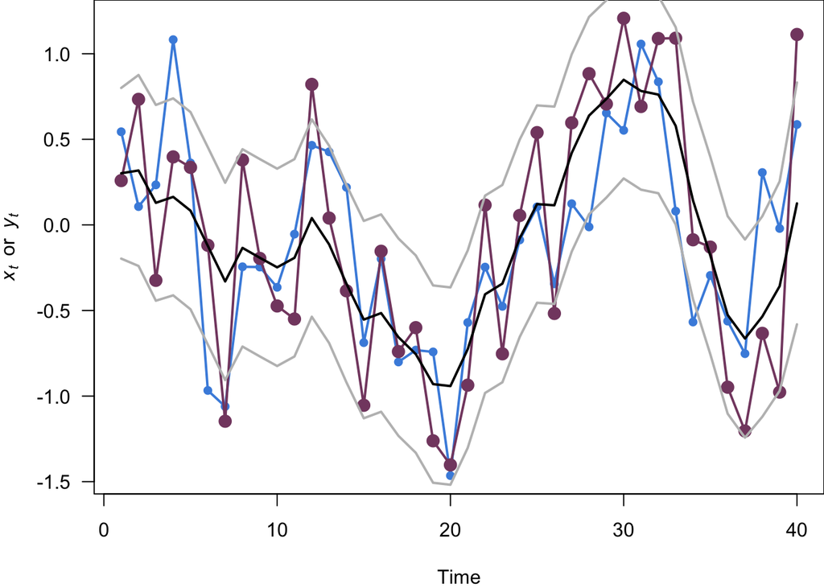

```r
par(mai = c(0.8,0.8,0,0), omi = c(0,0,0,0))
plot.ts(xx, lwd = 2, type = "o", pch = 16, col = "#488fdf",
        las = 1, ylim = c(min(xx,yy), max(xx,yy)),
        ylab = expression(italic(x[t])~~or~~italic(y[t])))
lines(yy, lwd = 2, type = "o", pch = 16, cex = 1.5, col = "#844870")
lines(mod_fits, lwd = 2, type = "l", cex = 1.5, col = "black")
lines(mod_fits_CI_hi, lwd = 2, type = "l", cex = 1.5, col = "gray")
lines(mod_fits_CI_lo, lwd = 2, type = "l", cex = 1.5, col = "gray")
```

## Evidence for bias

Q: Is there data support for the bias term?

To answer this, we can fit a model without the bias term and compare AICc

## Evidence for bias

We need to modify the model definition for `MARSS()` by setting `U = matrix(0)`

```r
mod_list <- list(
  ## state model
  B = matrix(1), U = matrix(0), Q = matrix("q"),
  ## obs model
  Z = matrix(1), A = matrix(0), R = matrix("r")
  )
```

## Re-fit the model with `MARSS()`

```r
## fit the model
mod_fit_2 <- MARSS(y = dat, model = mod_list)
```

```
## Success! algorithm run for 15 iterations. abstol and log-log tests passed.
## Alert: conv.test.slope.tol is 0.5.
## Test with smaller values (<0.1) to ensure convergence.
##
## MARSS fit is
## Estimation method: kem
## Convergence test: conv.test.slope.tol = 0.5, abstol = 0.001
## Algorithm ran 15 (=minit) iterations and convergence was reached.
## Log-likelihood: -42.13973
## AIC: 90.27947   AICc: 90.94613
##
##       Estimate
## R.r      0.244
## Q.q      0.121
## x0.x0    0.298
## Initial states (x0) defined at t=0
##
## Standard errors have not been calculated.
## Use MARSSparamCIs to compute CIs and bias estimates.
```

## Compare AIC values

```r
## biased RW
mod_fit$AICc
```

```
## [1] 93.41513
```

```r
## unbiased RW
mod_fit_2$AICc
```

```
## [1] 90.94613
```

## Fitting models with `MARSS()`

Recall that `MARSS()` uses an expanded form of state-space model, such that

$$\begin{align}
x_t &= b x_{t-1} + w_t \\
y_t &= x_t + v_t \\
& \Downarrow \\
x_t &= b x_{t-1} + u + w_t \\
y_t &= Z x_t + a + v_t
\end{align}$$

with $u = 0$, $Z = 1$, and $a = 0$

## Fitting models with `MARSS()`

State model  
$x_t = b x_{t-1} + u + w_t ~~ \text{with} ~~ w_t \sim \text{N}(0,q)$

Observation model  
$y_t = Z x_t + a + v_t ~~ \text{with} ~~ v_t \sim \text{N}(0,r)$

```r
mod_list <- list(
  ## state model
  B = matrix("b"), U = matrix(0), Q = matrix("q"),
  ## obs model
  Z = matrix(1), A = matrix(0), R = matrix("r")
  )
```

**Note**: `MARSS()` works with the `matrix` class in **R**, so we have to define any scalar as a $1 \times 1$ matrix

## Fitting models with `MARSS()`

We can ignore the `inits` and `control` arguments for now and fit the model

```r
## define the data as an N (rows) x T (cols) matrix
dat <- matrix(yy, nrow = 1, ncol = TT)
## fit the model
mod_fit <- MARSS(y = dat, model = mod_list)
```

## Fitting models with `MARSS()`

```
## Success! abstol and log-log tests passed at 20 iterations.
## Alert: conv.test.slope.tol is 0.5.
## Test with smaller values (<0.1) to ensure convergence.
##
## MARSS fit is
## Estimation method: kem
## Convergence test: conv.test.slope.tol = 0.5, abstol = 0.001
## Estimation converged in 20 iterations.
## Log-likelihood: -39.74432
## AIC: 87.48864   AICc: 88.6315
##
##       Estimate
## R.r      0.204
## B.b      0.722
## Q.q      0.169
## x0.x0    0.511
## Initial states (x0) defined at t=0
##
## Standard errors have not been calculated.
## Use MARSSparamCIs to compute CIs and bias estimates.
```